# Tema 04 - Introducción a RMarkdown

Universidad de Alicante, Curso 2021/22

## Introducción

- [R Markdown](http://rmarkdown.rstudio.com/index.html) proporciona un marco unificado para el análisis de datos **reproducible**: combina código, resultados y comentarios
- Útil tanto como cuaderno de trabajo con el código como para mostrar a quienes se centran en las conclusiones para tomar decisiones
- Integra paquetes de R (`rmarkdown` y `knitr`) y herramientas externas para producir documentos html, PDF, Word, presentaciones, etc.
- Recursos de Ayuda
  - En el menú de *Help* de RStudio (*Cheatsheets*)
  - [Libro online sobre R Markdown](https://bookdown.org/yihui/rmarkdown/).

## Crear un documento de R Markdown

- A partir de una plantilla en RStudio con o *File > New File > R Markdown*: se elige formato de salida (HTML, por defecto)
  - si `rmarkdown` no está instalado y cargado, RStudio pedirá instalarlo
- Se compila o renderiza con (“tejer”) a la opción por defecto (html) o desplegar para elegir otros formatos
  - en el botón contiguo (engranaje) se pueden cambiar algunas opciones
- Para crear PDFs, es necesario tener instalado una distribución de LaTeX

```r
install.packages("tinytex")
tinytex::install_tinytex()
```

- Practica a renderizar el documento de la plantilla en los tres formatos.

## Formato de texto con Markdown

- Los archivos `.Rmd` están escritos en Markdown: un conjunto ligero de convenciones para el formato de archivos de texto sin formato.

#### **Formato de texto**

```
*cursiva*  o _cursiva_
**negrita**   __negrita__
`código`
superíndice^2^ y subíndice~2~
~~tachado~~
```

#### **Encabezamientos**

```
# Encabezado de 1er. nivel
## Encabezado de 2º nivel
### Encabezado de 3er. nivel
#### Encabezado de 4º nivel
```

#### **Listas**

```
*   Item (elemento) de la lista (no numeradas)
*   Item 2
    - Sub-Item 2a (*, + y - son alternativas)
        + sub-sub-item
    - Sub-Item 2b

1.  Item 1 de la lista numerada
1.  Item 2. Los números se incrementan automáticamente.

1)  Otra forma de crear listas numeradas.
2)  También, se puede poner explícitamente el número.
```

## Formato de texto con Markdown (cont.)

#### **Bloques de citas literales**

```
> Esto es parte de un bloque de cita.
> Esto es parte del mismo bloque de cita.
```

#### **Notas a pie de página**

```
Esto es un texto con nota al pie [^nota1]
y esta es otra nota [^2]

[^nota1]: Esto es una nota al pie de página.
[^2]: Esto es la segunda nota al pie.
```

#### **Líneas de separación**

```
---
***
```

#### **Referencias**

```
[Página de R][1]
[1]: https://cran.r-project.org/

#### Título 1 {#tit1}
[Enlace a titulo1](#tit1)
```

#### **Imaǵenes y enlaces**

```
![texto del subtítulo opcional](dirección/hacia/img.png)
<http://example.com>
[frase con vínculo](http://example.com)
[![RUsers](http://rusersgroup.com/img/final5x5.png)](https://cran.r-project.org/ )
```

## Formato de texto con Markdown (y 3)

#### **Tablas**

```
Primer encabezado  | Segundo encabezado
------------------ | ------------------
Celda              | Celda
Celda              | Celda
```

##### Con alineación de columnas

```
| Items    | Cantidad | Precio   |
| :------- | :------: | -------: |
| Item 1   | 15       | 9,050    |
| Item 2   | 3250     | 239,99   |
```

- Se puede introducir código en HTML y en LaTeX (útil para [ecuaciones](https://www.latex4technics.com/))
  - ecuación en texto entre `$ $` o en editor visual , *Inline Math*
  - ecuación aparte entre `$$ $$` o en editor visual , *Displayed Math*
- Los comentarios se escriben entre `<!--` `-->`
- La barra \ delante de un símbolo muestra el símbolo, no aplica el formato: ej.,\* muestra *, no empieza lista (idem para \[ o \$ )

## Editor Visual de R Markdown en RStudio

- En documentos .Rmd clic en el botón o elegir la opción con el botón de engranaje
- En el modo visual, la **barra de herramientas** tiene accesos a todos los elementos de formato de texto y otros
  - También existen atajos de teclado (para RStudio, en general)

[figure not shown]

- Se puede configurar la corrección ortográfica en *Tools > Global Options > Spelling*
  - agregar/seleccionar el diccionario de Español
  - marcar corrección en tiempo real

## Fragmentos de código (“code chunks”)

- Código en medio del texto: p.e., `r 2+3` muestra 5
  - con el atajo `Ctrl + I`, con icono (visual) , o escribiendo entre ` `
- Fragmento de código (varias líneas)
  - en modo visual, icono y/o el desplegable
  - atajo de teclado `Ctrl + Alt + I`
  - escribiendo manualmente los delimitadores de fragmento

``` {r}

```

- Útil para mostrar resultados en el documento o solo el código (ilustración)

## Opciones básicas para fragmentos de código

\(\Rightarrow\) Estando en modo visual, en el icono de engranaje del fragmento, o bien separadas por comas en {r}

- El fragmento puede tener un nombre para referencias
- Mostar o no avisos, errores, mensajes al ejecutar el código
  - en el editor visual, marcar la opción para mostrar o no
  - establecer con `=` para `warning`, `error` o `message` el valor `TRUE` o `FALSE`
- `echo = TRUE` para mostrar el código (y `echo = FALSE` para no hacerlo)
- `eval = TRUE` para evaluar el código: los resultados de ejecutar el código están disponibles y pueden mostrarse (o no con `eval = FALSE`)
- La lista completa de opciones [aquí](http://yihui.name/knitr/options/)
  - (este enlace también aparece en el engranaje en visual)

## Otras opciones para fragmentos de código

- `results = hide`: no muestra los resultados
  - también otras opciones de *cómo* mostrarlos
- `fig.show`: *cómo* mostrar la figura
  - una opción es no mostrarla: `fig.show = hide`
- `include = FALSE`: no se incluye ni el código ni su resultado, pero se evalua
- `fig.width` y `fig.height` (o `fig.dim`): fijar las dimensiones de una figura
- `out.width` y `out.height`: dimensiones de una figura en el documento de salida (diferentes de lo anterior, que son las reales de la figura)
- `fig.align`: mostrar la figura centrada o alineada a derecha o izquierda

## Otras opciones para fragmentos de código (cont.)

- `fig.cap`: leyenda de la figura
- Combinando opciones para poner dos figuras una al lado de otra

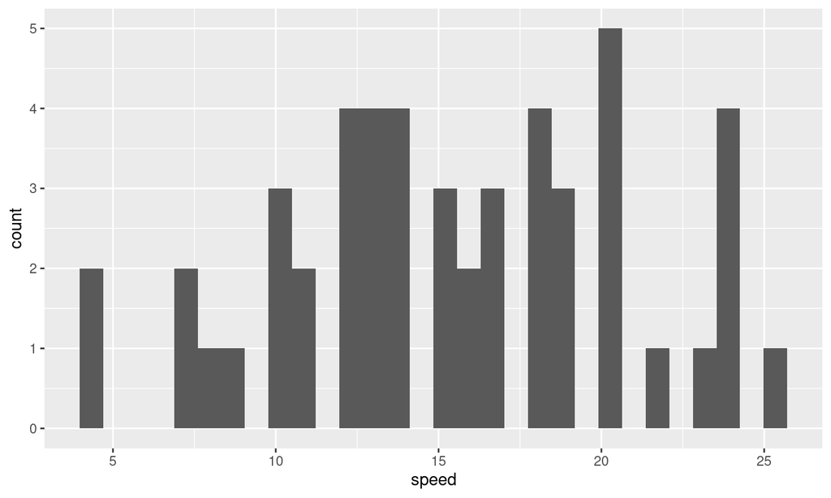

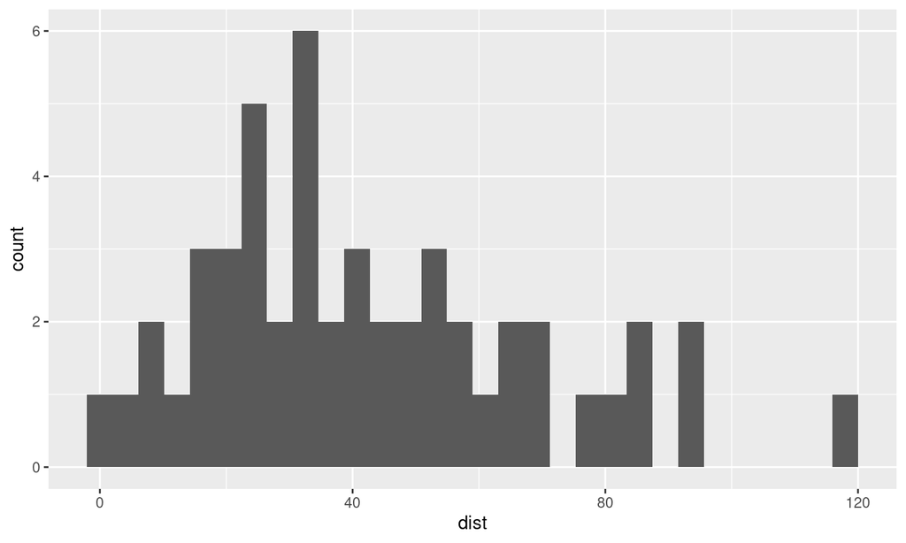

````r
# ```{r, echo=TRUE, fig.show="hold", out.width="50%"}
ggplot(data = cars) + geom_histogram(aes(x = speed))  # en la izquierda
ggplot(data = cars) + geom_histogram(aes(x = dist))   # en la derecha
````

## Opciones globales para fragmentos de código

- Si no se da un valor a las opciones en un fragmento, se utilizan el valor por defecto global en el documento.
- El comando `opts_chunk$set()` cambia esas opciones globales en un documento, por ejemplo,
  - `knitr::opts_chunk$set(echo=FALSE, fig.width=6, fig.height=6)`
- Suele incluirse en un fragmento al principio del documento
  - podéis verlo en el documento de la plantilla, con nombre `setup`
  - se suelen cargar también las bibliotecas necesarias
  - notad el `include = FALSE` (para no mostrar, pero sí evaluar)

## Ejecución de código en .Rmd

- Al renderizar un documento .Rmd, se crea un nuevo espacio de trabajo y se ejecuta el código allí.
  - ese espacio de trabajo es *distinto* del que vemos en RStudio: diferentes objetos, incluyendo bibliotecas
- Es importante conocer qué códigos evaluamos y los objetos disponibles en cada parte del documento
- Si ejecutamos código del documento .Rmd (no renderizando), éste pasa a la consola y *sí* forma parte del espacio de trabajo de la sesión actual de R.
- Se puede ejecutar línea a línea, un fragmento completo con o todos los anteriores con
- Útil para probar el código (antes de renderizar), pero debemos asegurarnos de que la sesión incluye sólo código de fragmentos del documento

## Formato en la cabecera `YAML`

- Especifica título, autor, etc. y opciones generales de visualización
- Al **principio del documento**, en modo visual, y elegir *YAML Block*

```
---
title: "Título"
author: Autor
date: 15 septiembre 2021
output:
  html_document:
    toc: true                   # índice
    number_sections: true       # secciones numeradas
    code_folding: hide          # ocultar código
    theme: united               # galería de temas: https://bootswatch.com/3/
---
```

## Formato en la cabecera `YAML` (cont.)

- Otras opciones interesantes: dimensiones de las figuras, mostrar datos por partes

  ```
   ---
   title: "Título"
   output:
     html_document:
       fig_width: 7
       fig_height: 6
       fig_caption: true
       df_print: paged
   ---
  ```

- Descripción completa de opciones (en inglés) [aquí](https://bookdown.org/yihui/rmarkdown/html-document.html).

## Mejorar la salida de tablas

- Los resultados muchos funciones de R no son visualmente “profesionales” en documentos de salida de .Rmd
- Varias bibliotecas cambian algunas salidas por defecto (`printr`) u ofrecen funciones para mejorarlas (`pander::pandoc.table()`, `xtable::xtable()`)
- Por ahora, veremos la biblioteca `knitr` ofrece la función `kable()`
- Más adelante veremos la biblioteca `kableExtra`, que extiende la funcionalidad de `knitr::kable()`: [ayuda](https://cran.r-project.org/web/packages/kableExtra/vignettes/awesome_table_in_html.html).
  - `kableExtra` muestra “data frame”/“tibbles” como tablas
  - `broom::tidy()` (de `tidyverse`) convierte mucho objetos de R (en particular, salidas de comandos) en “tibbles”
- Otra biblioteca interesante es `stargazer`